# Aviation Financials codebase

# Aviation Financials Introduction

I have chosen the dataset [Global Aviation Industry 2010-2026](https://www.kaggle.com/datasets/sergionefedov/global-aviation-industry-2010-2026?resource=download). I will be focusing on the airline financials dataset within the group of datasets for simplicity. I will be doing basic renaming and small transformations for this first assignment. This dataset is specifically about the financial situation of major airlines over the last 17 years. It includes the year, revenue, and total profit margin for each airline.

## Highest and lowest financial years

Looking at the highest and lowest years shows a very expected trend. The highest years will almost always be the current year. However, the lowest yearly revenue for the majority of these airlines is 2020. Covid affected the entire world of aviation.

The figures below shows us each airlines best and worst years. Showing revenue in billions of US dollars.

Highest Yearly Revenue

| Airline | Year | Revenue |
| --- | --- | --- |
| Delta Air Lines | 2026 | 68.38 |
| United Airlines | 2026 | 62.28 |
| American Airlines | 2026 | 57.72 |
| Southwest Airlines | 2026 | 32.34 |
| Alaska Airlines | 2026 | 13.17 |
| JetBlue | 2025 | 10.16 |
| Lufthansa Group | 2026 | 45.43 |
| IAG (British Airways) | 2026 | 36.71 |
| Air France-KLM | 2026 | 38.73 |
| Ryanair | 2026 | 16.21 |
| easyJet | 2026 | 12.04 |
| Turkish Airlines | 2026 | 26.42 |
| Aeroflot | 2019 | 10.26 |
| China Southern | 2026 | 29.11 |
| Air China | 2026 | 27.61 |
| China Eastern | 2026 | 22.65 |
| Japan Airlines | 2026 | 14.20 |
| ANA Holdings | 2026 | 20.19 |
| Singapore Airlines | 2026 | 17.37 |
| Cathay Pacific | 2026 | 15.37 |
| Korean Air | 2026 | 14.62 |
| IndiGo | 2026 | 9.71 |
| AirAsia | 2025 | 5.12 |
| Emirates | 2026 | 37.94 |
| Qatar Airways | 2026 | 24.72 |
| Etihad | 2015 | 9.05 |
| Saudia | 2026 | 9.49 |
| Riyadh Air | 2026 | 3.11 |
| LATAM Airlines | 2025 | 13.70 |
| Azul | 2026 | 4.85 |

Lowest Yearly Revenue

| Airline | Year | Revenue |
| --- | --- | --- |
| Delta Air Lines | 2020 | 18.23 |
| United Airlines | 2020 | 15.10 |
| American Airlines | 2020 | 17.63 |
| Southwest Airlines | 2020 | 9.30 |
| Alaska Airlines | 2020 | 3.52 |
| JetBlue | 2020 | 2.86 |
| Lufthansa Group | 2020 | 14.70 |
| IAG (British Airways) | 2020 | 9.55 |
| Air France-KLM | 2020 | 11.47 |
| Ryanair | 2021 | 1.59 |
| easyJet | 2021 | 1.99 |
| Turkish Airlines | 2010 | 5.56 |
| Aeroflot | 2022 | 4.22 |
| China Southern | 2010 | 10.89 |
| Air China | 2022 | 8.70 |
| China Eastern | 2022 | 7.16 |
| Japan Airlines | 2020 | 4.84 |
| ANA Holdings | 2020 | 6.53 |
| Singapore Airlines | 2020 | 2.93 |
| Cathay Pacific | 2021 | 5.63 |
| Korean Air | 2020 | 5.97 |
| IndiGo | 2010 | 0.87 |
| AirAsia | 2021 | 0.50 |
| Emirates | 2020 | 8.37 |
| Qatar Airways | 2010 | 7.20 |
| Etihad | 2020 | 2.51 |
| Saudia | 2020 | 2.57 |
| Riyadh Air | 2023 | 0.01 |
| LATAM Airlines | 2020 | 4.30 |
| Azul | 2010 | 0.39 |

## Total Global Aviation Yearly Revenue

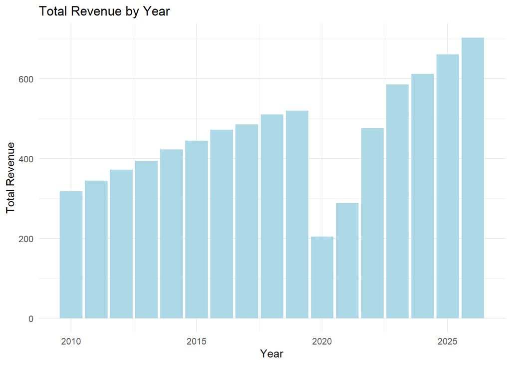

# Overview

These simple tables and bar graph show the impact that the covid-19 pandemic had on the aviation industry, but it does not yet tell a story of the recovery. While the current projections show a trend upwards there may be other factors that still need to be recovered that is not shown in the financials at this time. I would further this analysis with more a granular look at the different parts of the aviation industry and how they were affected. For instance, how much has been spent on repair and upkeep costs compared to delivery of fully knew aircrafts/engines and try to determine the sustainability of this growth through those data points.